# UtahConference

In *'../new/'* I am optimizing the convolutional neural network models.  
Here I recreate results from primer notebook with Lukasz's new data.

```python
%pylab inline
import os,sys,re
import numpy as np
import pandas as pd
import warnings
warnings.filterwarnings('ignore')
sys.path.append(os.path.abspath('../new/'))
from predictions_library import *

start, end = "\033[1m", "\033[0;0m" # this is to print bold


# load datasets
positives = open_fastas('./ARG3_O1_O2_clustered_rescored.fasta_bin14_threshold10.0_37923positives.fasta')
negatives = open_fastas('./ARG3_O1_O2_clustered_rescored.fasta_bg_37923negatives.fasta')
positives['TAD']=1
negatives['TAD']=0
data = pd.concat([pd.DataFrame(i) for i in [positives, negatives]], axis=0)

# get aa frequencies
for i in aa:
    data[i] = np.array([seq.count(i)/30. for seq in data.index])
```

#### What do we call positive and negative sets now?

```python
def fasta_header_extract(fileName):
    headers, sequences = [], []
    for i in open(fileName):
        if i[0]=='>':
            tmp = i.strip().split('_')
            headers.append(tmp)
            continue
        else:
            sequences.append(i.strip())
    values = np.array(headers)[:,1:6].astype(int)
    return pd.DataFrame(values, index=sequences, columns = ['bg','bin1','bin2','bin3','bin4'])

positives_bins = fasta_header_extract('./ARG3_O1_O2_clustered_rescored.fasta_bin14_threshold10.0_37923positives.fasta')
negatives_bins = fasta_header_extract('./ARG3_O1_O2_clustered_rescored.fasta_bin14_threshold10.0_37923positives.fasta')
```

```python
percent = positives_bins[(positives_bins['bin2']==0) & (positives_bins['bin3']==0) &
                         (positives_bins['bin4']==0)].shape[0] *1. / positives_bins.shape[0]*100

print(start + '{:.2f}%'.format(percent) + end +
      ' of samples in positives set don\'t have reads in bins>1. \nNegatives don\'t have ANY read in bins>0')
```

```
3.31% of samples in positives set don't have reads in bins>1.
Negatives don't have ANY read in bins>0
```

```python
positives_out = positives_bins[(positives_bins['bin2']==0) | (positives_bins['bin3']==0) | (positives_bins['bin4']==0)].index
data = data.loc[ set(data.index) - set(positives_out)]
```

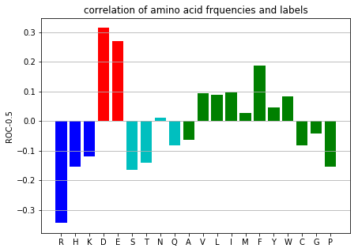

```python
from sklearn.metrics import roc_curve, auc, roc_auc_score

X = data[aa]
y = data.TAD

cols = []
for i in aa:
    if i=='E' or i=='D': cols.append('r')
    elif i=='R' or i=='K' or i=='H': cols.append('b')
    elif i=='S' or i=='T' or i=='N' or i=='Q': cols.append('c')
    else: cols.append('g')
r=[]
for i in aa:
    r.append(roc_auc_score(y, X[i].values))

pd.DataFrame(r, index=aa, columns=['AUC']).sort_values('AUC', ascending=False)

r=np.array(r)-0.5
plt.figure(figsize=(7,5))
plt.bar(aa, r, color=cols)
plt.ylabel('ROC-0.5')
plt.grid(which='major', axis='y')
plt.title('correlation of amino acid frquencies and labels');
#plt.savefig('correlation_of_amino_acid_frquencies_and_labels.jpg', dpi=600)
```

#### It looks like charge and amino-acid identities show some correlation with labels. Let's do a logistic regression analysis (using ROC_AUC as ojective function)

```python
from sklearn.linear_model import LogisticRegressionCV
from sklearn.metrics import make_scorer

idx = np.arange(data.shape[0])
np.random.seed=0
np.random.shuffle(idx)

_10 = len(idx)
_8, _9 = int(0.8*_10), int(0.9*_10)

_train = data.index[idx[:_8]]
_test = data.index[idx[_8:_9]]
_valid = data.index[idx[_9:]]

Xtrain, Xvalid = data.loc[_test, aa], data.loc[_valid, aa]
ytrain, yvalid = data.loc[_test, 'TAD'], data.loc[_valid, 'TAD']

linear_model = LogisticRegressionCV(Cs = np.linspace(1e-4, 1e4, 60), scoring = make_scorer(roc_auc_score)).fit(Xtrain, ytrain)

roc_auc_score(yvalid, linear_model.predict_proba(Xvalid)[:,1])
```

```
0.9731447659817526
```

The performance of the logistic regression was not correctly estimated, since I was using the labels and not the probabilities. Now is fixed

```python
charges = []
for i in aa:
    if i=='E' or i=='D': charges.append(-1)
    elif i=='R' or i=='K': charges.append(1)
    elif i==i=='H': charges.append(0.5)
    else: charges.append(0)
charges = np.array(charges)

1- roc_auc_score(yvalid, Xvalid.dot(charges))
```

```
0.9478521605945205
```

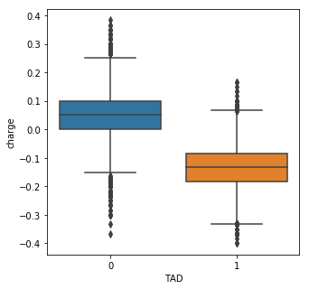

```python
import seaborn as sns
plt.figure(figsize=(5,5))
data['charge'] = data[aa].values.dot(charges)
#sns.violinplot(x=data['TAD'], y=data['charge'])
sns.boxplot(x=data['TAD'], y=data['charge'])
plt.savefig('violin_charges.jpg', dpi=900)
```

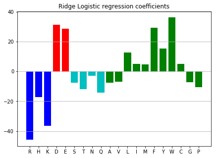

```python
plt.figure(figsize=(7,5))
plt.bar(aa, linear_model.coef_[0], color=cols)
plt.grid(which='major', axis='y')
plt.title('Ridge Logistic regression coefficients');
#plt.savefig('Ridge_Logistic_regression_coefficients.jpg', dpi=900)
```

```python
from itertools import product

for i in product(aa,aa):
    dipept = ''.join(i)
    data[dipept] = [seq.count(dipept)/29. for seq in data.index]
```

```python
X = data[[''.join(i) for i in product(aa,aa)]]
y = data.TAD

Xtrain, Xvalid = X.loc[_train], X.loc[_valid]
ytrain, yvalud = y.loc[_train], y.loc[_valid]

model2 = LogisticRegressionCV(Cs = np.linspace(1e-4, 1e4, 60), scoring = make_scorer(roc_auc_score)).fit(Xtrain, ytrain)
```

```python
weights = np.zeros(shape=(len(aa), len(aa)))

coefs = model2.coef_[0]
coefs = coefs - np.min(coefs) / (np.max(coefs)-np.min(coefs))

for position, value in zip([i for i in product(aa,aa)], coefs):
    x,y = aa.index(position[0]), aa.index(position[1])
    weights[x][y] = value


roc_auc_score(yvalid, model2.predict_proba(Xvalid)[:,1])
```

```
0.9776776594414783
```

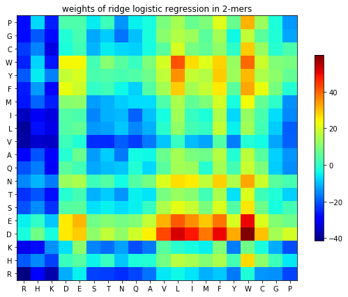

```python
f, ax = plt.subplots(1, figsize=(9,7))
im = ax.pcolor(weights, cmap='jet')
ax.set_xticks(np.arange(20)+0.5)
ax.set_yticks(np.arange(20)+0.5)
ax.set_xticklabels(aa)
ax.set_yticklabels(aa);
plt.colorbar(im, shrink=0.7)
plt.title('weights of ridge logistic regression in 2-mers');
#plt.savefig('weights_of_ridge_logistic_regression_in_2_mers.jpg', dpi=1200)
```

```python
# Check that the matrix is showing corrects weights
_60_DW = list(X.columns).index('DW')
_40_DY = list(X.columns).index('DY')
_0_SQ = list(X.columns).index('SQ')
__40_VH = list(X.columns).index('VH')

for i in [_60_DW, _40_DY, _0_SQ, __40_VH]:
    print(model2.coef_[0][i])
```

```
59.516712238900816
32.19461203023923
-5.082952429887197
-34.86294935988797
```

- Very clear in the figure: It appears that there might be a correlation between "D" or "E" followed by a bulky aminoacid to TAD activity.
- What is more remarkable in this picture is that there seems to be a direction in which this 2mer is stronger and the reverse complement does not necessarily correlate with TAD activtity.

#### I run a quick optimization of convolutional neural network models and here I choose the best model to observe features of individual samples and to test individual known activators

```python
deep_models = pd.read_csv('../new/convolutional_training.results', index_col=0)
deep_models.max(axis=1).sort_values(ascending=False)
new_index = [i.replace('$',"") for i in deep_models.index]
deep_models.set_index(np.array(new_index), inplace=True)

for i in ['combinations', 'n_filters', 'w_filters','dense1','dense2']:
    deep_models[i] = 0

for i in deep_models.index:
    combinations , n_filters, w_filters, dense1, dense2 = i.split('_')

    for j in ['combinations', 'n_filters','w_filters','dense1','dense2']:
        deep_models.loc[i, j] = eval(j)
```

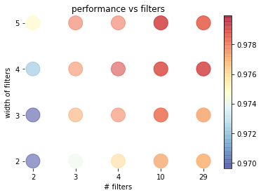

```python
jets = plt.cm.get_cmap('RdYlBu_r')

deep_models['M'] = deep_models[['rep'+str(i) for i in range(1,11)]].max(axis=1)
#cols = (cols - np.min(cols)) / (np.max(cols)-np.min(cols))

combinations =  [['sequences',' ss_psipred'],
                 ['sequences', 'ss_psipred', 'disorder_long'],
                 ['sequences', 'ss_psipred', 'disorder_short'],
                 ['sequences', 'disorder_short'],
                 ['sequences', 'disorder_long'],
                 ['sequences'],
                 ['ss_psipred'],
                 ['ss_psipred', 'disorder_short', 'disorder_long']]

subset = deep_models[deep_models.combinations=='0']
cols = subset['M'].values

im = plt.scatter(subset.n_filters, subset.w_filters, c=cols, cmap=jets, s=400, alpha=0.5, marker='o')
plt.colorbar(im)
plt.xlabel('# filters'); plt.ylabel('width of filters')
plt.title('performance vs filters')
plt.box(False);
plt.savefig('performance_vs_filters.jpg', dpi=1200)
```

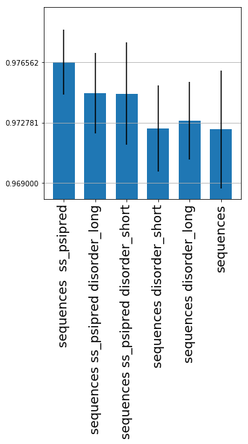

```python
subset2 = deep_models[(deep_models.w_filters=='4') &
                      (deep_models.n_filters=='10') &
                      (deep_models.dense1=='300') &
                      (deep_models.dense2=='30')]


combinations =  [['sequences',' ss_psipred'],
                 ['sequences', 'ss_psipred', 'disorder_long'],
                 ['sequences', 'ss_psipred', 'disorder_short'],
                 ['sequences', 'disorder_short'],
                 ['sequences', 'disorder_long'],
                 ['sequences']]#,
                 #['ss_psipred'],
                 #['ss_psipred', 'disorder_short', 'disorder_long']]

subset2 = subset2.iloc[:6]
xlabels = [' '.join(i) for i in combinations]

#plt.figure(figsize=(15,5))
#plt.subplot(121)
#plt.bar(xlabels, subset2.av, width=0.35, yerr=subset2.sd)
#plt.xticks(rotation=90)

#plt.subplot(122)
plt.figure(figsize=(5,5))
plt.bar(xlabels, subset2.av, width=0.7, yerr=subset2.sd)
plt.ylim(0.968, 0.98)
plt.xticks(rotation=90, fontsize=18)
plt.yticks(np.linspace(0.969, subset2.av.max(), 3))
plt.grid(which='major', axis='y')
plt.savefig('compare_models_secondary_structure.jpg', dpi=300)
```

- The more filters we use, the better the results for low filter widths, although in the upper right corner we are approaching an equillibrium. This might be the consecuence of finding the correct filters by chance (since filters are selected randomly).
- The performance is greatly improved with the width of the filter, with filters 4-5 residues long reaching highest performance.

```python
deep_models['M'].sort_values(ascending=False).head(5)
```

```
0_29_4_300_30    0.979949
0_10_5_300_30    0.979426
2_10_4_300_30    0.979417
0_10_4_300_30    0.979400
2_29_5_20_6      0.979137
Name: M, dtype: float64
```

```python
# prepare dfs. IMPORTANT: these "properties.fasta" contain MUCH more sequences than positive+negative.
# Reduce it to the index that will be used and discard ALL sequences that are not going to be used.
reduced_index, labels = data.index, data.TAD

# load and get ohe matrices of all secondary structures and disorder
ss_psipred = load_predicted_properties('../from_scratch/30mers_ALL.PSIPRED_ss.fasta')
ss_psipred_set = list(set(np.concatenate([i for i in ss_psipred.values])))
# One hot encode all categorical variables
def ohe_wrap(data, categories): return np.array([ohe(data.loc[i], categories) for i in reduced_index])
ss_psipred = ohe_wrap(ss_psipred, ss_psipred_set)

# combine all variables together, categorical and numerical
sequences = np.array([ohe(seq, aa) for seq in reduced_index])
ohe_data = np.vstack([sequences.T, ss_psipred.T]).T
```

```
../from_scratch/30mers_ALL.PSIPRED_ss.fasta loaded succesfully!
```

```python
import keras.backend as K
from keras.layers import Dense, Conv2D, Flatten, AveragePooling2D, Input, Dropout
from keras.models import Model
from keras.callbacks import EarlyStopping
from keras.activations import softplus, softsign


# Split data 8:1:1
idx = np.arange(ohe_data.shape[0])
np.random.seed=0
np.random.shuffle(idx)
_8, _9 = int(ohe_data.shape[0]*0.8), int(ohe_data.shape[0]*0.9)
train, test, valid = idx[:_8], idx[_8:_9], idx[_9:]

shape = ohe_data.shape
ohe_data = ohe_data.reshape(tuple(list(shape)+[1]))

# define the sets with ALWAYS same split
Xtrain, Xtest, Xvalid = [ohe_data[i] for i in [train, test, valid]]
ytrain, ytest, yvalid = [labels[i] for i in [train, test, valid]]

'''R=0
for repeat in range(30):
    K.clear_session()

    inputs = Input(shape=(30,Xtrain.shape[2],1))
    x = Conv2D(29, (4,Xtrain.shape[2]), activation=softplus)(inputs)
    #x = AveragePooling2D((1,1))(x)
    x = Flatten()(x)
    x = Dense(300, activation=softplus)(x)
    x = Dropout(0.3)(x)
    x = Dense(30, activation=softplus)(x)
    output = Dense(1, activation='sigmoid')(x)
    model = Model(inputs=inputs, outputs=output)
    model.compile(optimizer='adam', loss='binary_crossentropy', metrics=['accuracy'])
    model.fit(Xtrain, ytrain,
              epochs=100,
              validation_split=0.1,
              callbacks=[EarlyStopping(patience=2)],
              verbose=0)

    y_hat = model.predict(Xvalid)
    r = roc_auc_score(yvalid, y_hat)
    if abs(r-0.5)>R:
        R=r
        winner = model.to_json()
        model.save_weights('winner_weights.h5')
        model_winner = model.copy()

f_winner = open('model_winner.json')
f_winner.write(model_json)
f_winner.close()
''';
```

```python
# Due to technical reasons, optimization of the model was done with a sbatch command.
from keras.models import model_from_json

K.clear_session()
inputs = Input(shape=(30,Xtrain.shape[2],1))
x = Conv2D(29, (4,Xtrain.shape[2]), activation=softplus)(inputs)
x = Flatten()(x)
x = Dense(300, activation=softplus)(x)
x = Dropout(0.3)(x)
x = Dense(30, activation=softplus)(x)
output = Dense(1, activation='sigmoid')(x)
deep_model = Model(inputs=inputs, outputs=output)

# before compiling the model, load the winner weights
deep_model.load_weights('../winner_weights.h5')

# compile with winner weights
deep_model.compile(optimizer='adam', loss='binary_crossentropy', metrics=['accuracy'])

roc_auc_score(yvalid, deep_model.predict(Xvalid))
```

```
0.9849946512683079
```

```python
def roc_curve(X,y, points):
    # make sure X and y are numpy arrays
    X,y = np.array(X), np.array(y)
    # thresholds to use for defining fpr and tpr
    scale = np.linspace(X.min(), X.max(), points)
    # define fpr and tpr functions to use with different thresholds
    def tpr(y_hat, y):
        a,b = set(np.hstack(np.where(y==1))), set(np.hstack(np.where(y_hat==1)))
        return(len(a & b) / len(a))
    def fpr(y_hat, y):
        a,b = set(np.hstack(np.where(y==0))), set(np.hstack(np.where(y_hat==1)))
        return(len(a & b) / len(a))
    # Core of the function where TPR and FPR are calculated
    TPR, FPR = np.zeros(points), np.zeros(points)
    for n,s in enumerate(scale):
        # threshold of variable defines what is + and -
        y_hat = np.array([1 if x>=s else 0 for x in X])
        TPR[n] = tpr(y_hat, y)
        FPR[n] = fpr(y_hat, y)
    # the resulting array will contain thresholds, fpr and tpr
    roc = np.vstack([scale, FPR, TPR])
    return(roc)

roc_auc_score(yvalid, deep_model.predict(Xvalid))
```

```
0.9849946512683079
```

```python
# linear

Xtrain2, Xvalid2 = data.loc[_test, aa], data.loc[_valid, aa]
ytrain2, yvalid2 = data.loc[_test, 'TAD'], data.loc[_valid, 'TAD']

print(roc_auc_score(yvalid2, linear_model.predict_proba(Xvalid2)[:,1]))
```

```
0.9731447659817526
```

```python
# 2-mers

X = data[[''.join(i) for i in product(aa,aa)]]
y = data.TAD

Xtrain3, Xvalid3 = X.loc[_train], X.loc[_valid]
ytrain3, yvalid3 = y.loc[_train], y.loc[_valid]

model2 = LogisticRegressionCV(Cs = np.linspace(1e-4, 1e4, 60), scoring = make_scorer(roc_auc_score)).fit(Xtrain3, ytrain3)

roc_auc_score(yvalid3, model2.predict_proba(Xvalid3)[:,1])
```

```
0.9776776594414783
```

```
assuming probabilities for y
linear_auc: 0.973
deep_auc: 0.985
_2mer_auc: 0.978
linear_acc: 0.917
deep_acc: 0.935
_2mer_acc: 0.929
```

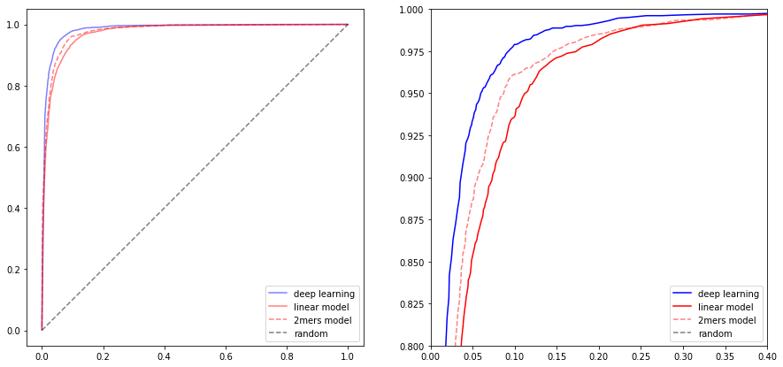

```python
_, fpr, tpr = roc_curve(deep_model.predict(Xvalid), yvalid, 100)
_, fpr2, tpr2 = roc_curve(linear_model.predict_proba(Xvalid2)[:,1], yvalid2, 100)
_, fpr3, tpr3 = roc_curve(model2.predict_proba(Xvalid3)[:,1], yvalid3, 100)

def accuracy(x,y):
    # check x & y are labels or probabilities
    for i in [x,y]:
        if len(x.shape)>1: x = np.concatenate(x)
        if len(y.shape)>1: y = np.concatenate(y)
    if set(x) != {0,1}:
        print('assuming probabilities for x')
        x = np.array([1 if i>=0.5 else 0 for i in x])
    if set(y) != {0,1}:
        print('assuming probabilities for y')
        y = np.array([1 if i>=0.5 else 0 for i in y])
    return np.sum(x==y) / x.shape[0]

linear_auc = roc_auc_score(yvalid2, linear_model.predict_proba(Xvalid2)[:,1])
_2mer_auc = roc_auc_score(yvalid3, model2.predict_proba(Xvalid3)[:,1])
deep_auc = roc_auc_score(yvalid, deep_model.predict(Xvalid))
linear_acc = accuracy(yvalid2, linear_model.predict(Xvalid2))
deep_acc = accuracy(yvalid, deep_model.predict(Xvalid))
_2mer_acc = accuracy(yvalid3, model2.predict(Xvalid3))

for i in ['linear_auc', 'deep_auc', '_2mer_auc', 'linear_acc', 'deep_acc', '_2mer_acc']:
    print('{}: {:.3f}'.format(i, eval(i)))

plt.figure(figsize=(15,7))

plt.subplot(121)
plt.plot(fpr, tpr, c='b', label='deep learning', alpha=0.5)
plt.plot(fpr2, tpr2, c='r', label='linear model', alpha=0.5)
plt.plot(fpr3, tpr3, c='r', label='2mers model', alpha=0.5, ls='--')
plt.plot([0,1],[0,1], ls='--', alpha=0.5, c='k', label='random')
plt.legend()

plt.subplot(122)
plt.plot(fpr, tpr, c='b', label='deep learning')
plt.plot(fpr2, tpr2, c='r', label='linear model')
plt.plot(fpr3, tpr3, c='r', label='2mers model', alpha=0.5, ls='--')
plt.plot([0,0],[1,1], ls='--', alpha=0.5, c='k', label='random')
plt.legend()
plt.xlim(0, 0.4)
plt.ylim(0.8, 1.0)

plt.savefig('roc_curves.jpg', dpi=1200)
```

## Finally

- a few plots showing features that deep_learning use to classify samples as TADs.(for this, find samples that are missclasified by linear models and correctly assigned in deep learning)
- plots of predictor showing TADs in known activators

```python
np.where(yvalid==1)[0][:10]
```

```
array([ 9, 18, 23, 24, 31, 33, 40, 41, 43, 49])
```

# ORDERNAR LA DF CON LOS INDICES QUE SEAN AMINOACIDO Y SECONDARY STRUCTURE COMBINADOS Y SUMAR SUS VALORES PARA PLOTT. (EX. 4_W_ssH

```
Evaluated output channel (0-based index): All
Building gradient functions
Progress: 100.0%
Done.
```

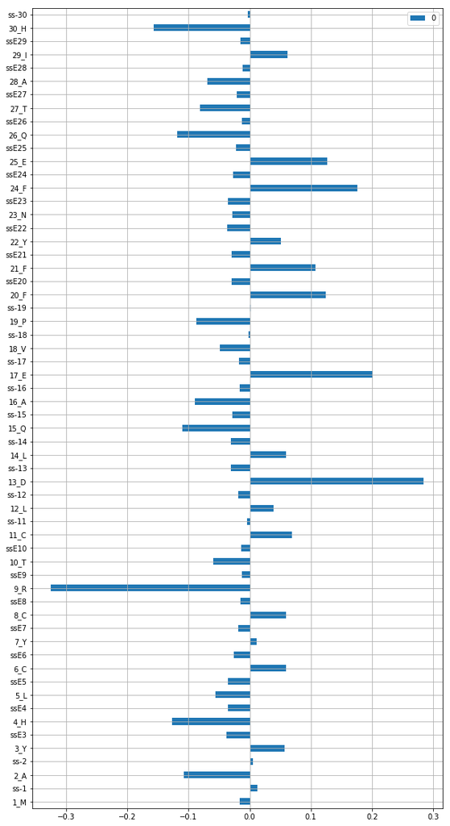

```python
from IntegratedGradients import *

ig = integrated_gradients(deep_model)
grads = ig.explain(Xvalid[24]).reshape(30,23)
seqs = np.array([[str(n)+'_'+i for n in range(1,31)] for i in aa])
sss = ['ss-'+str(i) for i in range(1,31)], ['ssE'+str(i) for i in range(1,31)], ['ssH'+str(i) for i in range(1,31)]
indx = labels = np.vstack([seqs, sss]).T
grads = pd.DataFrame(np.concatenate(grads), index=np.concatenate(indx))
grads = grads[(grads>0) | (grads<0)].dropna()

grads.plot.barh(figsize=(10,20)); plt.grid()

qPlus = ['R','K','H']
qMinus= ['D','E']
aa_properties = ['']
```

```python
# one hot encode the data
def one_hot_label(matrix): #matrix.shape=30,23,1 --> e.g. Xtrain[0]
    seq, ss = [],[]
    for i in range(30):
        # first get sequence
        idx = np.where(np.concatenate(matrix[i])==1)[0][0]
        seq.append(aa[idx])
        # second get secondary structure
        idx = np.where(np.concatenate(Xtrain[0][i])==1)[0][1]
        ss.append(ss_psipred_set[idx-20])

        seq = ''.join(seq)
        ss = ''.join(ss)

    return seq, ss
```

correr ss_psipred en gcn4, met4, gal4, ino2

```python
ino2 = protein_from_sgd('INO2')
```

```python
ino2
```

```
'MQQATGNELLGILDLDNDIDFETAYQMLSSNFDDQMSAHIHENTFSATSPPLLTHELGII…'
```

```python
train[0]
```

```
57352
```

```python
data.index[train[0]]
```

```
'SGNVTCRYRITDDRKARYFAGYGNSKGTNP'
```

```python
ss_psipred[train[0]]
```

```
array([[0., 0., 1.],
       [0., 0., 1.],
       [0., 0., 1.],
       [1., 0., 0.],
       [1., 0., 0.],
       [1., 0., 0.],
       [1., 0., 0.],
       [1., 0., 0.],
       [1., 0., 0.],
       [1., 0., 0.],
       [0., 0., 1.],
       [0., 0., 1.],
       [0., 0., 1.],
       [0., 0., 1.],
       [0., 0., 1.],
       [0., 0., 1.],
       [1., 0., 0.],
       [1., 0., 0.],
       [1., 0., 0.],
       [0., 0., 1.],
       [0., 0., 1.],
       [0., 0., 1.],
       [0., 0., 1.],
       [0., 0., 1.],
       [0., 0., 1.],
       [0., 0., 1.],
       [0., 0., 1.],
       [0., 0., 1.],
       [0., 0., 1.],
       [0., 0., 1.]])
```

```python
ss_psipred_set
```

```
['E', 'H', '-']
```

```python
for n,i in enumerate(list(good)):
    print(n,i)
```

```
0 0.0
1 0.0
2 0.0
3 0.0
4 0.0
5 0.0
6 0.0
7 0.0
8 0.0
9 0.0
10 0.0
11 0.0
12 0.0
13 0.0
14 0.0
15 0.0
16 0.0
17 0.0
18 0.08101465225219727
19 0.08437619209289551
20 0.0
21 0.0
22 -0.03609382390975952
23 -0.022266767024993896
24 0.039391393661499026
25 0.0
26 0.0
27 0.0
28 0.0
29 0.0
```